# Proposed Minimum and Guidance Levels for Lake Starr in Polk County, Florida

Nathan Johnson

DRAFT, July 2015

# Executive Summary

This report describes the development of proposed Minimum and Guidance levels for Lake Starr in Polk County, Florida based on reevaluation of levels in Southwest Florida Water Management District rules that became effective August 2000. Minimum levels are the levels at which further water withdrawals would be significantly harmful to the water resources of the are (Section 373.042(1)(b), F.S.). Adopted minimum levels are used to support water resource planning and permitting activities. Adopted guidance levels are used as advisory guidelines for construction of lake shore development, water dependent structures, and operation of water management structures.

The Lake Starr water budget was built over the period 1988-2012. Lake elevation data was available over this period.

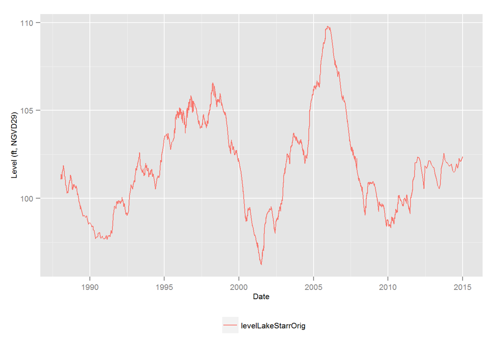

The Upper Floridan aquifer well near Lake Starr was filled using Romp 57 to present a more complete dataset for the water budget model.

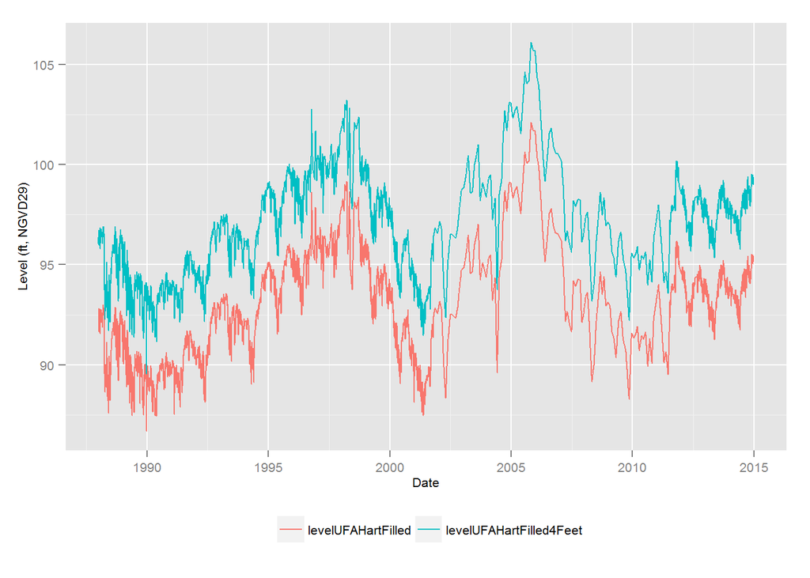

Composite rainfall was coverted from in/day into ft3/day for the water budget model.

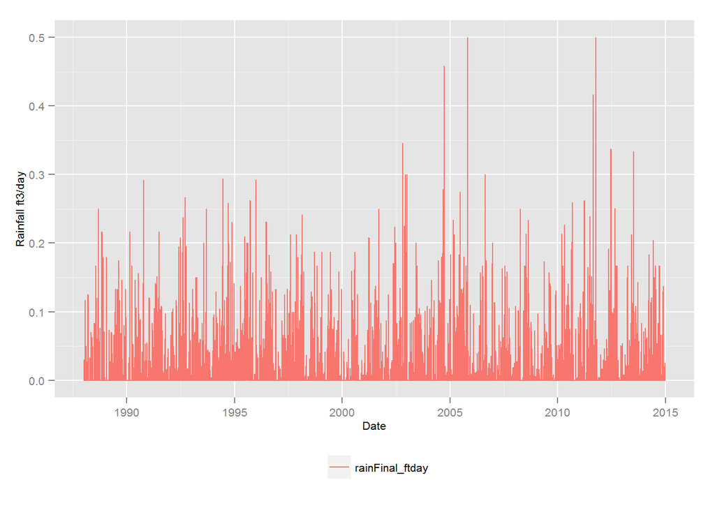

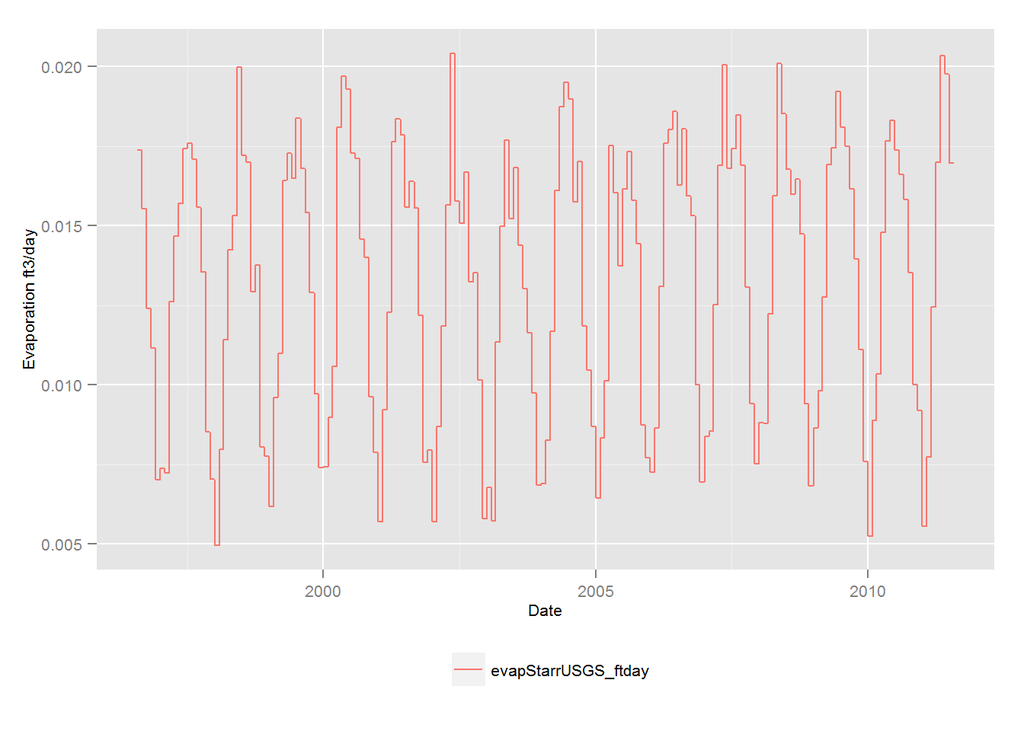

Leakage from the lake was captured by a coefficient to determine the interaction between the underlying aquifer and the lake.

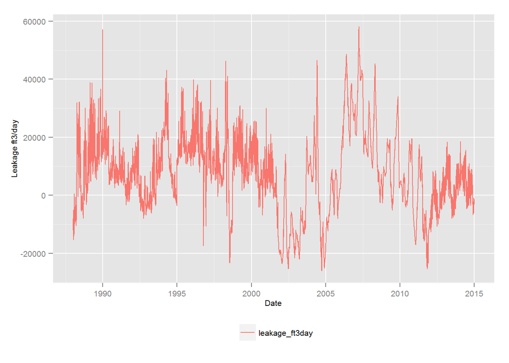